# LGEP vs. EW Prediction

Adam Festa

2/4/2019

## Purpose

The purpose of this script is to conduct predictions with ridge, lasso, and OmicKriging on the EW families using the LGEP families

## Load starting data

- Load the LGEP vs EW data & R packages

```r
library(glmnet); library(doParallel); library(ggplot2)
library(ggpubr); library(OmicKriging); library(caret)
load("../../../shared/lgep.vs.ew.data.RData")
names(lgep.vs.ew.data)
```

```
## [1] "train.counts" "train.snps"   "train.phenos" "test.counts"
## [5] "test.snps"    "test.phenos"
```

```r
registerDoParallel(cores=detectCores())
```

## Ridge/Lasso/OK

- Ridge/Lasso prediction using transcripts or SNPs works as follows:
1. Training data is used with phenotype data with generic glment function to determine variables which are non-zero
2. Variables which are non-zero are then subset from the training data and used with CV.glment function conducting LOO to build model used to predict test set (EW families)
- OmicKriging prediction was done as follows:
1. Training data is used with phenotypes to test correlation weights 0.1 to 1.0 by 0.1 to choose a correlation weight to use on test data. This was done using a LOO for each weight and then choosing the correlation weight which gave the lowest RMSE across all individuals.
2. The specified correlation weight was then used with training data to predict ew families
- Predict EW families using txpts with Ridge, Lasso, & OmicKriging

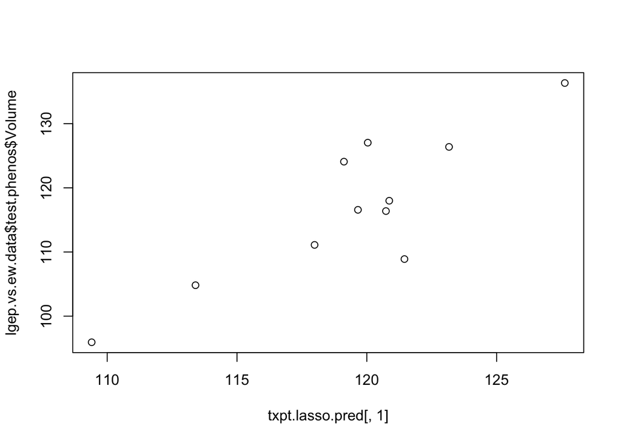

```r
  # First transcripts ridge/lasso
  pval.train <- lgep.vs.ew.data$train.counts
  pval.test <- lgep.vs.ew.data$test.counts

  gl.mod <- glmnet(x = pval.train,y =lgep.vs.ew.data$train.phenos$Volume,alpha = 1,standardize = F)

  # Extract coefficients from model
  gl.mod1 <- as.matrix(coef(gl.mod))
  # For each row (covariate) in matrix determine the unique length of values
    # The first row corresponds to intercept so it is removed from final vector.
    # The first column is all 0's so there has to be more than 1 unique value in order for the covariate to be non-zero
  gl.mod1 <- apply(gl.mod1,1,function(x) length(unique(x)))[-1]
  these <-  which(gl.mod1 > 1)
  lasso.cv <- cv.glmnet(x = pval.train[,names(these)],y = lgep.vs.ew.data$train.phenos$Volume,parallel = T,alpha=1,nfolds = 45,grouped = F,standardize=F,type.measure = "mae")

  txpt.lasso.pred <- predict.cv.glmnet(object = lasso.cv,newx = pval.test[,these],s = lasso.cv$lambda.min)
  plot(txpt.lasso.pred[,1],lgep.vs.ew.data$test.phenos$Volume)
```

```r
  cor(txpt.lasso.pred[,1],lgep.vs.ew.data$test.phenos$Volume)
```

```
## [1] 0.8688378
```

```r
    RMSE(txpt.lasso.pred,lgep.vs.ew.data$test.phenos$Volume)
```

```
## [1] 7.726779
```

```r
  txpt.lasso.features <- names(these)

pt <- proc.time()
  ridge.cv <- cv.glmnet(x = pval.train,y = lgep.vs.ew.data$train.phenos$Volume,parallel = T,alpha=0,nfolds = 45,grouped = F,standardize=F,type.measure = "mae")
    print(proc.time()-pt)
```

```
##    user  system elapsed
## 211.727  93.968 122.845
```

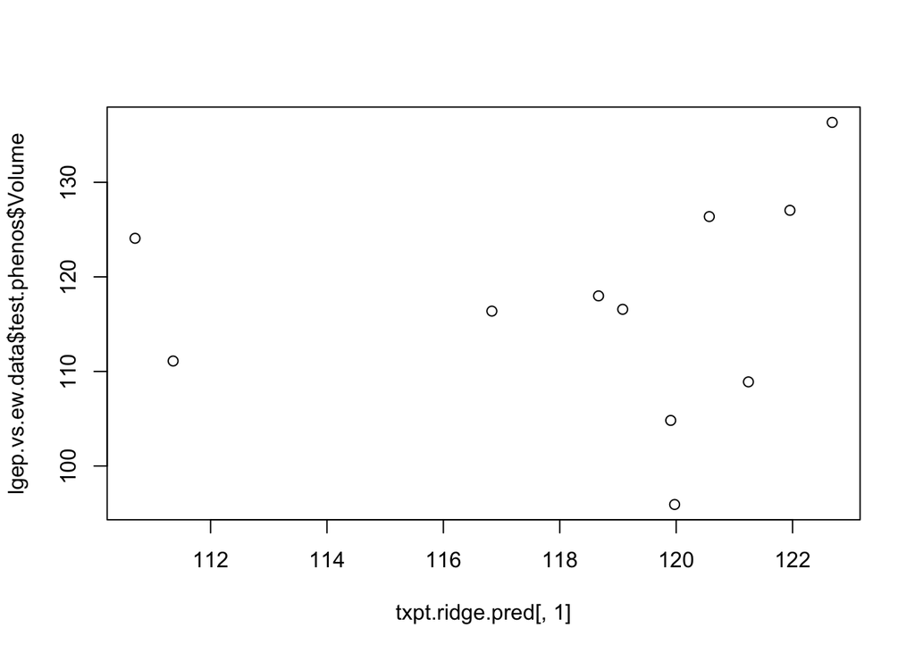

```r
  txpt.ridge.pred <- predict.cv.glmnet(object = ridge.cv,newx = pval.test,s = ridge.cv$lambda.min)
  plot(txpt.ridge.pred[,1],lgep.vs.ew.data$test.phenos$Volume)
```

```r
  cor(txpt.ridge.pred[,1],lgep.vs.ew.data$test.phenos$Volume)
```

```
## [1] 0.1143675
```

```r
  RMSE(txpt.ridge.pred,lgep.vs.ew.data$test.phenos$Volume)
```

```
## [1] 11.24176
```

```r
  # transcripts OK
  x.train <- cor(t(pval.train))
  y.train <- lgep.vs.ew.data$train.phenos
  all.weights <- seq(.1,1,.1)

  train.rmse <- unlist(lapply(1:length(all.weights),function(each.weight){
    this.w <- all.weights[each.weight]
    ok.preds <- lapply(1:nrow(y.train),function(each.cv){
      ok.pred <- okriging(idtest = y.train$fam_id[each.cv],idtrain = y.train$fam_id[-each.cv],corlist = list(x.train),H2vec = c(this.w),pheno = y.train,phenoname = "Volume")
    })
    ok.preds <-do.call(rbind,ok.preds)
    RMSE(ok.preds[,2],ok.preds[,3])
  }))

  final.weight <- all.weights[which.min(train.rmse)]
  all.d <- rbind(pval.train,pval.test)
  all.p <- rbind(y.train,lgep.vs.ew.data$test.phenos)
  x.cor <- cor(t(all.d))
  pt <- proc.time()
  ok.pred <- okriging(idtest = lgep.vs.ew.data$test.phenos$fam_id,idtrain = lgep.vs.ew.data$train.phenos$fam_id,corlist = list(x.cor),H2vec = c(final.weight),pheno = all.p ,phenoname = "Volume")
    print(proc.time()-pt)
```

```
##    user  system elapsed
##   0.003   0.001   0.009
```

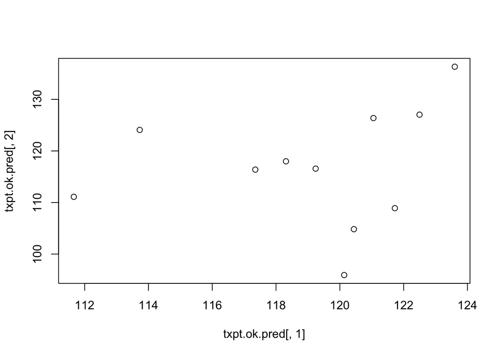

```r
  txpt.ok.pred <- ok.pred[,-c(1)]
  plot(txpt.ok.pred[,1],txpt.ok.pred[,2])
```

```r
  cor(txpt.ok.pred[,1],txpt.ok.pred[,2])
```

```
## [1] 0.206254
```

```r
  txpt.predictions <- list("true.phenos"=txpt.ok.pred[,2],"lasso.pred"=txpt.lasso.pred,"ridge.pred"=txpt.ridge.pred,"ok.pred"=txpt.ok.pred,"lasso.feats"=txpt.lasso.features)
```

- Predict EW families using SNPs with Ridge, Lasso, & OmicKriging

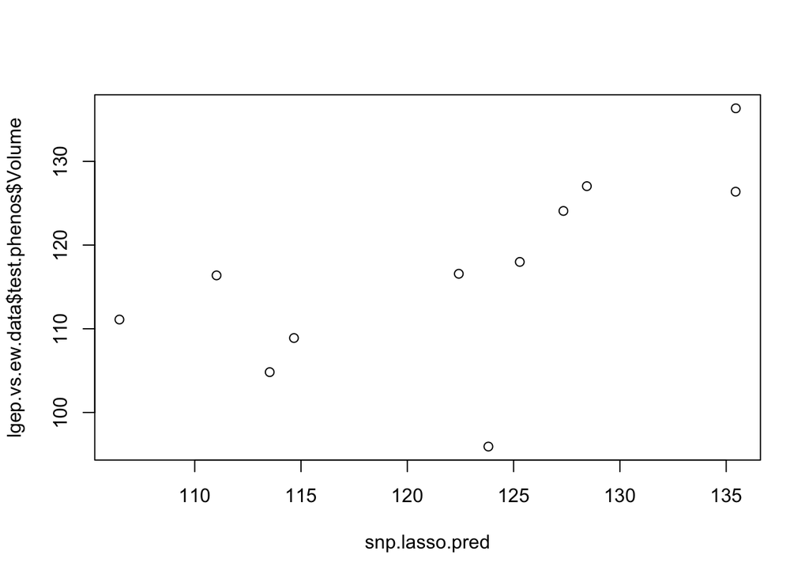

```r
  # Next snps ridge/lasso
  pval.train <- as.matrix(lgep.vs.ew.data$train.snps)
  pval.test <- as.matrix(lgep.vs.ew.data$test.snps)

  gl.mod <- glmnet(x = pval.train,y =lgep.vs.ew.data$train.phenos$Volume,alpha = 1,standardize = F)
  gl.mod1 <- as.matrix(coef.glmnet(gl.mod))
  gl.mod1 <- apply(gl.mod1,1,function(x) length(unique(x)))[-1]
  these <-  which(gl.mod1 > 1)
  lasso.cv <- cv.glmnet(x = pval.train[,names(these)],y = lgep.vs.ew.data$train.phenos$Volume,parallel = T,alpha=1,nfolds = 45,grouped = F,standardize=F,type.measure = "mae")

  snp.lasso.pred <- predict.cv.glmnet(object = lasso.cv,newx = pval.test[,names(these)],s = lasso.cv$lambda.min)
  snp.lasso.features <- names(these)
  plot(snp.lasso.pred,lgep.vs.ew.data$test.phenos$Volume)
```

```r
  cor(snp.lasso.pred,lgep.vs.ew.data$test.phenos$Volume)
```

```
##        [,1]
## 1 0.6473171
```

```r
  RMSE(snp.lasso.pred,lgep.vs.ew.data$test.phenos$Volume)
```

```
## [1] 10.09011
```

```r
  pt <- proc.time()
  ridge.cv <- cv.glmnet(x = pval.train,y = lgep.vs.ew.data$train.phenos$Volume,parallel = T,alpha=0,nfolds = 45,grouped = F,standardize=F,type.measure = "mae")
  print(proc.time()-pt)
```

```
##    user  system elapsed
## 115.041  68.275  86.139
```

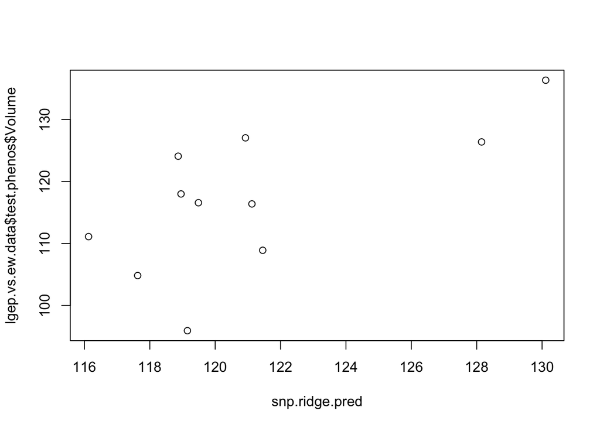

```r
  snp.ridge.pred <- predict.cv.glmnet(object = ridge.cv,newx = pval.test,s = ridge.cv$lambda.min)
    plot(snp.ridge.pred,lgep.vs.ew.data$test.phenos$Volume)
```

```r
  cor(snp.ridge.pred,lgep.vs.ew.data$test.phenos$Volume)
```

```
##        [,1]
## 1 0.6756929
```

```r
  RMSE(snp.ridge.pred,lgep.vs.ew.data$test.phenos$Volume)
```

```
## [1] 9.650685
```

```r
  # snps OK
  x.train <- cor(t(pval.train))
  y.train <- lgep.vs.ew.data$train.phenos
  all.weights <- seq(.1,1,.1)

  train.rmse <- unlist(lapply(1:length(all.weights),function(each.weight){
    this.w <- all.weights[each.weight]
    ok.preds <- lapply(1:nrow(y.train),function(each.cv){
      ok.pred <- okriging(idtest = y.train$fam_id[each.cv],idtrain = y.train$fam_id[-each.cv],corlist = list(x.train),H2vec = c(this.w),pheno = y.train,phenoname = "Volume")
    })
    ok.preds <-do.call(rbind,ok.preds)
    RMSE(ok.preds[,2],ok.preds[,3])
  }))

  final.weight <- all.weights[which.min(train.rmse)]
  all.d <- rbind(pval.train,pval.test)
  all.p <- rbind(y.train,lgep.vs.ew.data$test.phenos)
  x.cor <- cor(t(all.d))
  pt <- proc.time()
  ok.pred <- okriging(idtest = lgep.vs.ew.data$test.phenos$fam_id,idtrain = lgep.vs.ew.data$train.phenos$fam_id,corlist = list(x.cor),H2vec = c(final.weight),pheno = all.p ,phenoname = "Volume")
    print(proc.time()-pt)
```

```
##    user  system elapsed
##   0.002   0.000   0.002
```

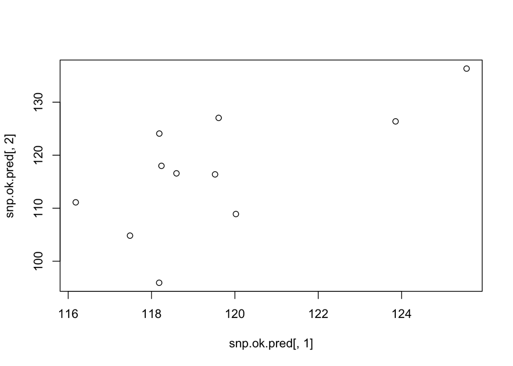

```r
  snp.ok.pred <- ok.pred[,-1]
  plot(snp.ok.pred[,1],snp.ok.pred[,2])
```

```r
  cor(snp.ok.pred[,1],snp.ok.pred[,2])
```

```
## [1] 0.6838795
```

```r
  snp.predictions <- list("true.phenos"=snp.ok.pred[,2],"lasso.pred"=snp.lasso.pred,"ridge.pred"=snp.ridge.pred,"ok.pred"=snp.ok.pred,"lasso.feats"=snp.lasso.features)
```

- Save output

```r
ew.lgep.results <- list("snps"=snp.predictions,"txpts"=txpt.predictions)
save(ew.lgep.results,file = "../../../shared/lgep.vs.ew.ridge.lasso.ok.V3.RData",compress=T)
```